# Univariate Model

13 October, 2014

# Preamble

All necessary files are sourced here. Not shown.

# Basic Info

The following will show a simple multilevel model to serve as a starting point to a multivariate setting. Comparisons of results will be made to output from the R pacakges *lme4*.

# Generate Data

First we generate the data given Andres’ function which is sourced in the preamble. In the following we will have 3 scores (S) per student, of which there are 50 students (n) in each of 10 classrooms (J). $\tau$ regards the covariance matrix for the random effects, while $\sigma$ regards the residual covariance matrix.

Since in this example we are only dealing with the univariate setting, the data is then divided according to score of interest, each of which may hten serve as an example.

```r
S = 3
n = 50
J = 10
Tau = matrix(c(1, 0, 0,
               0, 1, 0,
               0, 0, 1), nrow = 3, byrow = TRUE)

Sigma = matrix(c(1, 0, 0,
                 0, 2^2, 0,
                 0, 0, 3^2), nrow = 3, byrow = TRUE)
Mu = c(70, 80, 90)

schooldat = dataGenHMLM2(S=S, n=n, J=J, mu=Mu,
                         Tau = Tau,
                         Sigma =  Sigma)
str(schooldat)
```

```
## 'data.frame':    1500 obs. of  12 variables:
##  $ S     : int  1 2 3 1 2 3 1 2 3 1 ...
##  $ n     : int  1 1 1 2 2 2 3 3 3 4 ...
##  $ J     : int  1 1 1 1 1 1 1 1 1 1 ...
##  $ idL2  : int  1 1 1 2 2 2 3 3 3 4 ...
##  $ idL3  : int  1 1 1 1 1 1 1 1 1 1 ...
##  $ mu    : num  70 80 90 70 80 90 70 80 90 70 ...
##  $ e     : num  -1.24 2.71 1.51 0.52 2.48 ...
##  $ y     : num  68.4 82.5 91.1 70.2 82.3 ...
##  $ beta_j: num  69.6 79.8 89.6 69.6 79.8 ...
##  $ ind1  : num  1 0 0 1 0 0 1 0 0 1 ...
##  $ ind2  : num  0 1 0 0 1 0 0 1 0 0 ...
##  $ ind3  : num  0 0 1 0 0 1 0 0 1 0 ...
##  - attr(*, "out.attrs")=List of 2
##   ..$ dim     : int  3 50 10
##   ..$ dimnames:List of 3
##   .. ..$ Var1: chr  "Var1=1" "Var1=2" "Var1=3"
##   .. ..$ Var2: chr  "Var2= 1" "Var2= 2" "Var2= 3" "Var2= 4" ...
##   .. ..$ Var3: chr  "Var3= 1" "Var3= 2" "Var3= 3" "Var3= 4" ...
```

```r
# Create subsets
library(dplyr)
score1 = schooldat %>%
  filter(S==1)
score2 = schooldat %>%
  filter(S==2)
score3 = schooldat %>%
  filter(S==3)
```

# Stan code for univariate model

First we create the model in Stan. One thing to note is the prior mean for the intercept is set to the overall mean, but otherwise we have a normal distribution for the intercept and random effect, and half-cauchy for the sd/variance parameters.

## Model code

```r
stanmodelcode = '
data {
  int<lower=1> N;                             // number of students per class * number of classes
  int<lower=1> J;                             // number of classes
  vector<lower=0>[N] y;                       // Response: test scores
  int<lower=1,upper=J> classroom[N];          // student classroom
}

parameters {
  real Intercept;                             // overall mean
  real<lower=0> sd_int;                       // sd for ints
  real<lower=0> sigma_y;                      // residual sd
  vector[J] mu;                               // classroom effects
}

transformed parameters {
  vector[N] yhat;                             // Linear predictor
  for (n in 1:N)
    yhat[n] <- mu[classroom[n]];
}

model {
  // priors
  Intercept ~ normal(80, 10);                 // example of weakly informative priors (and ignoring Matt trick for now);
  mu ~ normal(Intercept, sd_int);
  sd_int ~ cauchy(0, 2.5);
  sigma_y ~ cauchy(0, 2.5);

  // likelihood
  y ~ normal(yhat, sigma_y);
}

generated quantities{
  real<lower=0, upper=1>  ICC;

  ICC <- (sd_int^2)/(sd_int^2+sigma_y^2);
}
'
```

## Test run

Next comes a test run. This is simply to check for compilation, typos, and if there are coding issues that might result in slow convergence. The run is kept small, and while we glance at the output, it really is of not too much interest at this point.

### Create Stan data list

```r
score1StanTest = list(J=J, N=n*J, y=score1$y, classroom=score1$J)
```

```r
testiter = 2000
testwu = 1000
testthin = 10
testchains = 2


library(rstan)
fitTest = stan(model_code = stanmodelcode, model_name = "test",
               data = score1StanTest, iter = testiter, warmup=testwu, thin=testthin,
               chains = testchains, verbose = F, refresh=1000)
```

[output not shown]

```r
### Summarize
print(fitTest, digits_summary=3, pars=c('Intercept','mu','sigma_y', 'sd_int', 'ICC'),
      probs = c(.025, .5, .975))
```

```
## Inference for Stan model: test.
## 2 chains, each with iter=2000; warmup=1000; thin=10;
## post-warmup draws per chain=100, total post-warmup draws=200.
##
##             mean se_mean    sd   2.5%    50%  97.5% n_eff  Rhat
## Intercept 69.930   0.025 0.342 69.262 69.914 70.680   192 1.003
## mu[1]     69.621   0.010 0.138 69.353 69.618 69.883   200 1.008
## mu[2]     68.709   0.010 0.135 68.425 68.714 68.979   200 1.003
## mu[3]     69.460   0.011 0.154 69.181 69.467 69.737   200 1.006
## mu[4]     69.693   0.011 0.129 69.417 69.694 69.946   143 0.992
## mu[5]     70.494   0.010 0.145 70.240 70.497 70.799   200 1.009
## mu[6]     69.204   0.010 0.135 68.949 69.218 69.457   200 0.996
## mu[7]     70.522   0.010 0.146 70.233 70.519 70.830   200 1.003
## mu[8]     70.367   0.011 0.152 70.096 70.360 70.654   200 0.999
## mu[9]     71.708   0.011 0.159 71.413 71.712 72.034   200 1.011
## mu[10]    69.147   0.011 0.148 68.857 69.144 69.419   192 1.012
## sigma_y    1.024   0.003 0.035  0.958  1.025  1.089   168 1.000
## sd_int     1.015   0.019 0.255  0.630  0.983  1.629   187 0.998
## ICC        0.481   0.008 0.117  0.266  0.482  0.697   191 1.000
##
## Samples were drawn using NUTS(diag_e) at Mon Oct 13 14:54:08 2014.
## For each parameter, n_eff is a crude measure of effective sample size,
## and Rhat is the potential scale reduction factor on split chains (at
## convergence, Rhat=1).
```

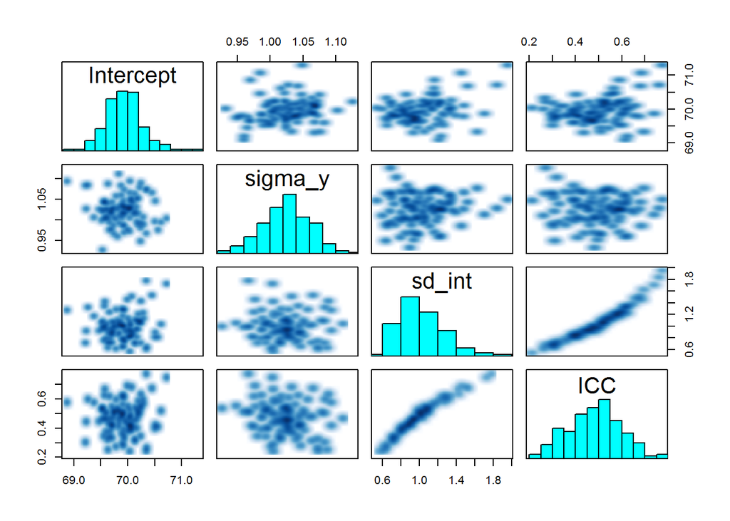

```r
pairs(fitTest, pars=c('Intercept','sigma_y', 'sd_int', 'ICC'))
```

```r
### Compare
library(lme4)
mod_lme = lmer(y~1+ (1|J), score1)
summary(mod_lme)
```

```
## Linear mixed model fit by REML ['lmerMod']
## Formula: y ~ 1 + (1 | J)
##    Data: score1
##
## REML criterion at convergence: 1476
##
## Scaled residuals:
##    Min     1Q Median     3Q    Max
## -2.934 -0.722  0.011  0.665  3.274
##
## Random effects:
##  Groups   Name        Variance Std.Dev.
##  J        (Intercept) 0.801    0.895
##  Residual             1.041    1.020
## Number of obs: 500, groups:  J, 10
##
## Fixed effects:
##             Estimate Std. Error t value
## (Intercept)   69.893      0.287     244
```

```r
ranef(mod_lme)$J + fixef(mod_lme)
```

```
##    (Intercept)
## 1        69.61
## 2        68.70
## 3        69.45
## 4        69.72
## 5        70.50
## 6        69.21
## 7        70.51
## 8        70.37
## 9        71.71
## 10       69.15
```

```r
print(fitTest, digits_summary=3, pars='mu')
```

```
## Inference for Stan model: test.
## 2 chains, each with iter=2000; warmup=1000; thin=10;
## post-warmup draws per chain=100, total post-warmup draws=200.
##
##         mean se_mean    sd  2.5%   25%   50%   75% 97.5% n_eff  Rhat
## mu[1]  69.62   0.010 0.138 69.35 69.53 69.62 69.72 69.88   200 1.008
## mu[2]  68.71   0.010 0.135 68.42 68.64 68.71 68.79 68.98   200 1.003
## mu[3]  69.46   0.011 0.154 69.18 69.35 69.47 69.56 69.74   200 1.006
## mu[4]  69.69   0.011 0.129 69.42 69.62 69.69 69.77 69.95   143 0.992
## mu[5]  70.49   0.010 0.145 70.24 70.40 70.50 70.57 70.80   200 1.009
## mu[6]  69.20   0.010 0.135 68.95 69.11 69.22 69.29 69.46   200 0.996
## mu[7]  70.52   0.010 0.146 70.23 70.42 70.52 70.62 70.83   200 1.003
## mu[8]  70.37   0.011 0.152 70.10 70.27 70.36 70.47 70.65   200 0.999
## mu[9]  71.71   0.011 0.159 71.41 71.61 71.71 71.80 72.03   200 1.011
## mu[10] 69.15   0.011 0.148 68.86 69.05 69.14 69.26 69.42   192 1.012
##
## Samples were drawn using NUTS(diag_e) at Mon Oct 13 14:54:08 2014.
## For each parameter, n_eff is a crude measure of effective sample size,
## and Rhat is the potential scale reduction factor on split chains (at
## convergence, Rhat=1).
```

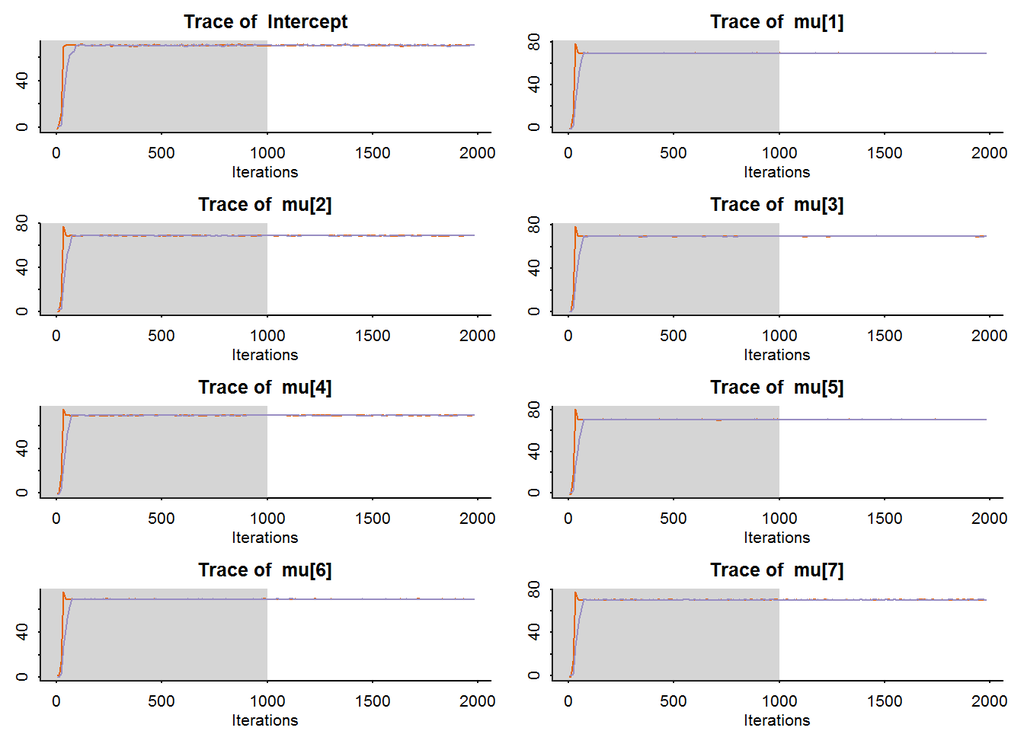

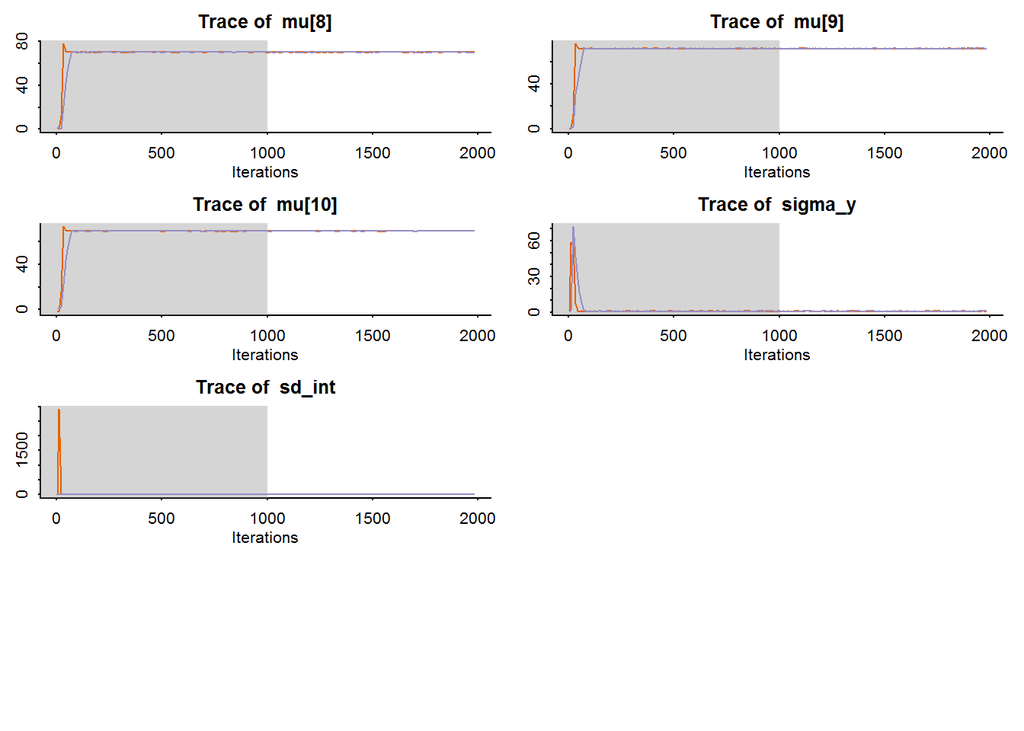

```r
### Diagnostic plots
traceplot(fitTest, pars=c('Intercept','mu','sigma_y', 'sd_int'))
```

```r
# traceplot(fitTest, pars=c('Intercept','mu','sigma_y', 'sd_int'), inc_warmup=F)
```

Comparison to *lme4* suggests the code is on the right track.

## Main run

Here we do the main run, bumping up the iterations and number of chains, though in parallel.

```r
###############################
### A parallelized approach ###
###############################
library(rstan)
iters = 12000
wu = 2000
thin = 10
chains = 4


library(parallel)
cl = makeCluster(chains)
clusterEvalQ(cl, library(rstan))
```

```
## [[1]]
##  [1] "rstan"     "inline"    "Rcpp"      "graphics"  "grDevices" "utils"     "datasets"  "methods"   "stats"     "base"
##
## [[2]]
##  [1] "rstan"     "inline"    "Rcpp"      "graphics"  "grDevices" "utils"     "datasets"  "methods"   "stats"     "base"
##
## [[3]]
##  [1] "rstan"     "inline"    "Rcpp"      "graphics"  "grDevices" "utils"     "datasets"  "methods"   "stats"     "base"
##
## [[4]]
##  [1] "rstan"     "inline"    "Rcpp"      "graphics"  "grDevices" "utils"     "datasets"  "methods"   "stats"     "base"
```

```r
clusterExport(cl, c('stanmodelcode', 'score1StanTest', 'fitTest', 'iters', 'wu', 'thin'))
p = proc.time()
parfit = parSapply(cl, 1:chains, function(i) stan(model_code = stanmodelcode, model_name = "schools",
                                             fit = fitTest, data = score1StanTest, iter = iters,
                                             warmup=wu, thin=thin, chains = 1, chain_id=i,
                                             verbose = T, refresh=4000),
                   simplify=F)
proc.time() - p
```

```
##    user  system elapsed
##    3.10    0.36    6.63
```

```r
stopCluster(cl)

# combine the chains
fitMain = sflist2stanfit(parfit)

# examine some diagnostics
ainfo = get_adaptation_info(fitMain)
cat(ainfo[[1]])
```

```
## # Adaptation terminated
## # Step size = 0.581122
## # Diagonal elements of inverse mass matrix:
## # 0.127516, 0.0745538, 0.00104921, 0.0185053, 0.0222861, 0.0215473, 0.0195702, 0.0191286, 0.0208815, 0.0204031, 0.0202525, 0.0187019, 0.0221636
```

```r
samplerpar = get_sampler_params(fitMain)[[1]]
summary(samplerpar)
```

```
##  accept_stat__     stepsize__      treedepth__   n_leapfrog__    n_divergent__
##  Min.   :0.000   Min.   :0.0005   Min.   :1.0   Min.   :  1.00   Min.   :0
##  1st Qu.:0.812   1st Qu.:0.5811   1st Qu.:3.0   1st Qu.:  7.00   1st Qu.:0
##  Median :0.917   Median :0.5811   Median :3.0   Median :  7.00   Median :0
##  Mean   :0.868   Mean   :0.5958   Mean   :2.8   Mean   :  6.71   Mean   :0
##  3rd Qu.:0.977   3rd Qu.:0.5811   3rd Qu.:3.0   3rd Qu.:  7.00   3rd Qu.:0
##  Max.   :1.000   Max.   :2.1367   Max.   :8.0   Max.   :255.00   Max.   :0
```

```r
print(fitMain, pars= c('Intercept','mu','sigma_y', 'sd_int', 'ICC'), digits=3,
      probs = c(.025, .5, 0.975))
```

```
## Inference for Stan model: test.
## 4 chains, each with iter=12000; warmup=2000; thin=10;
## post-warmup draws per chain=1000, total post-warmup draws=4000.
##
##             mean se_mean    sd   2.5%    50%  97.5% n_eff  Rhat
## Intercept 69.902   0.005 0.338 69.254 69.907 70.601  3889 1.000
## mu[1]     69.610   0.002 0.144 69.320 69.611 69.894  3633 1.002
## mu[2]     68.703   0.002 0.145 68.423 68.702 68.993  4000 1.000
## mu[3]     69.453   0.002 0.141 69.176 69.452 69.727  4000 0.999
## mu[4]     69.713   0.002 0.144 69.432 69.713 69.997  3970 1.000
## mu[5]     70.506   0.002 0.145 70.224 70.507 70.788  4000 1.001
## mu[6]     69.212   0.002 0.143 68.930 69.213 69.491  3865 0.999
## mu[7]     70.513   0.002 0.144 70.227 70.515 70.792  4000 1.000
## mu[8]     70.369   0.002 0.144 70.093 70.367 70.651  3963 1.000
## mu[9]     71.709   0.002 0.147 71.423 71.709 71.991  4000 1.000
## mu[10]    69.147   0.002 0.144 68.871 69.148 69.434  4000 0.999
## sigma_y    1.023   0.001 0.033  0.959  1.022  1.089  4000 1.000
## sd_int     1.024   0.005 0.290  0.616  0.970  1.754  3978 1.000
## ICC        0.483   0.002 0.124  0.268  0.474  0.745  4000 1.000
##
## Samples were drawn using NUTS(diag_e) at Mon Oct 13 14:54:29 2014.
## For each parameter, n_eff is a crude measure of effective sample size,
## and Rhat is the potential scale reduction factor on split chains (at
## convergence, Rhat=1).
```

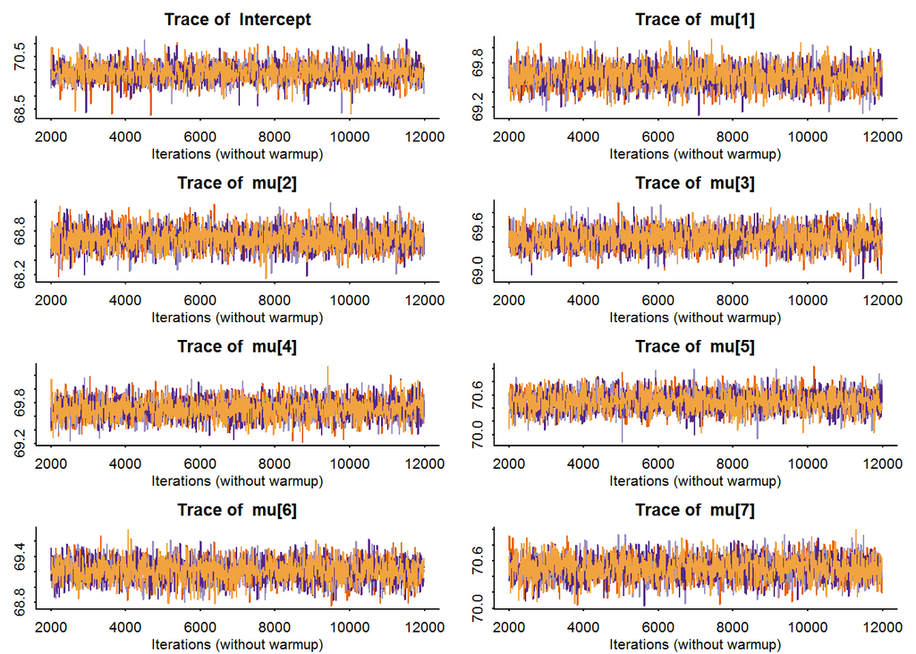

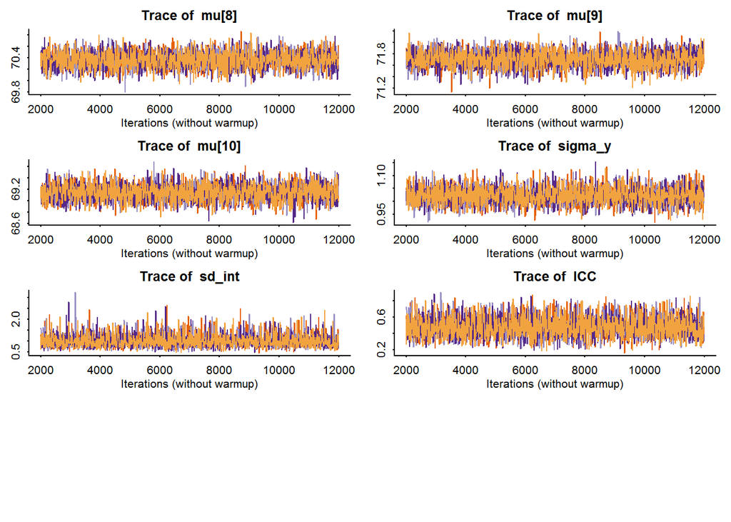

```r
# diagnostics
traceplot(fitMain, inc_warmup=F, pars=c('Intercept','mu','sigma_y', 'sd_int', 'ICC'))
```

## Comparison to lme4

```r
# library(lme4); library(dplyr)

mod_lme = lmer(y~1+ (1|J), data=score1)
summary(mod_lme)
```

```
## Linear mixed model fit by REML ['lmerMod']
## Formula: y ~ 1 + (1 | J)
##    Data: score1
##
## REML criterion at convergence: 1476
##
## Scaled residuals:
##    Min     1Q Median     3Q    Max
## -2.934 -0.722  0.011  0.665  3.274
##
## Random effects:
##  Groups   Name        Variance Std.Dev.
##  J        (Intercept) 0.801    0.895
##  Residual             1.041    1.020
## Number of obs: 500, groups:  J, 10
##
## Fixed effects:
##             Estimate Std. Error t value
## (Intercept)   69.893      0.287     244
```

```r
ranef(mod_lme)
```

```
## $J
##    (Intercept)
## 1      -0.2839
## 2      -1.1928
## 3      -0.4407
## 4      -0.1758
## 5       0.6111
## 6      -0.6794
## 7       0.6195
## 8       0.4752
## 9       1.8140
## 10     -0.7472
```

# Stan with optimized code

The following shows one optimization for the random effect. We also switch to Score 2.

```r
stanmodelcodeOpt = '
data {
  int<lower=1> N;                             // number of students per class * number of classes
  int<lower=1> J;                             // number of classes
  vector<lower=0>[N] y;                       // Response: test scores
  int<lower=1,upper=J> classroom[N];          // student classroom
}

parameters {
  real Intercept;                             // overall mean
  real<lower=0> sd_int;                       // sd for ints
  real<lower=0> sigma_y;                      // residual sd
  vector[J] mu;                               // classroom effects
}

transformed parameters {
  vector[N] yhat;                             // Linear predictor
  for (n in 1:N)
    yhat[n] <- Intercept + mu[classroom[n]]*sd_int;
}

model {
  // priors
  Intercept ~ normal(80, 10);                 // example of weakly informative priors (and ignoring Matt trick for now);
  mu ~ normal(0, 1);
  sd_int ~ cauchy(0, 2.5);
  sigma_y ~ cauchy(0, 2.5);

  // likelihood
  y ~ normal(yhat, sigma_y);
}

generated quantities{
  real<lower=0, upper=1>  ICC;

  ICC <- (sd_int^2)/(sd_int^2 + sigma_y^2);

}
'

score2StanTest = list(J=J, N=n*J, y=score2$y, classroom=score2$J)

library(rstan)
iters = 12000
wu = 2000
thin = 10
chains = 4


library(parallel)
cl = makeCluster(chains)
clusterEvalQ(cl, library(rstan))
```

```
## [[1]]
##  [1] "rstan"     "inline"    "Rcpp"      "graphics"  "grDevices" "utils"     "datasets"  "methods"   "stats"     "base"
##
## [[2]]
##  [1] "rstan"     "inline"    "Rcpp"      "graphics"  "grDevices" "utils"     "datasets"  "methods"   "stats"     "base"
##
## [[3]]
##  [1] "rstan"     "inline"    "Rcpp"      "graphics"  "grDevices" "utils"     "datasets"  "methods"   "stats"     "base"
##
## [[4]]
##  [1] "rstan"     "inline"    "Rcpp"      "graphics"  "grDevices" "utils"     "datasets"  "methods"   "stats"     "base"
```

```r
clusterExport(cl, c('stanmodelcodeOpt', 'score2StanTest', 'fitTest', 'iters', 'wu', 'thin'))
p = proc.time()
parfit = parSapply(cl, 1:chains, function(i) stan(model_code = stanmodelcodeOpt,
                                                  model_name = "schools",
                                                  data = score2StanTest, iter = iters,
                                                  warmup=wu, thin=thin, chains = 1, chain_id=i,
                                                  refresh=4000),
                   simplify=F)
proc.time() - p
```

```
##    user  system elapsed
##    0.46    0.17   44.56
```

```r
stopCluster(cl)

# combine the chains
fitMain = sflist2stanfit(parfit)

# summary
print(fitMain, pars= c('Intercept','mu','sigma_y', 'sd_int', 'ICC'), digits=3,
      probs = c(.025, .05, .5, 0.975))
```

```
## Inference for Stan model: schools.
## 4 chains, each with iter=12000; warmup=2000; thin=10;
## post-warmup draws per chain=1000, total post-warmup draws=4000.
##
##             mean se_mean    sd   2.5%     5%    50%  97.5% n_eff  Rhat
## Intercept 79.770   0.004 0.267 79.233 79.338 79.775 80.302  3647 1.000
## mu[1]     -0.319   0.008 0.477 -1.264 -1.100 -0.327  0.609  3733 1.000
## mu[2]     -0.429   0.008 0.481 -1.387 -1.238 -0.420  0.479  4000 1.000
## mu[3]     -0.013   0.007 0.468 -0.925 -0.780 -0.012  0.904  3930 1.000
## mu[4]     -0.123   0.008 0.475 -1.099 -0.913 -0.119  0.802  4000 1.001
## mu[5]     -1.134   0.008 0.528 -2.259 -2.042 -1.105 -0.191  4000 1.000
## mu[6]      1.304   0.009 0.538  0.311  0.457  1.288  2.446  3770 1.000
## mu[7]     -1.126   0.009 0.524 -2.196 -2.042 -1.102 -0.171  3502 1.000
## mu[8]      0.776   0.008 0.494 -0.152 -0.009  0.750  1.805  3522 1.000
## mu[9]     -0.173   0.008 0.465 -1.069 -0.925 -0.169  0.732  3780 1.000
## mu[10]     1.261   0.009 0.543  0.276  0.416  1.237  2.398  3776 0.999
## sigma_y    2.009   0.001 0.064  1.883  1.904  2.008  2.139  3577 1.001
## sd_int     0.788   0.004 0.245  0.430  0.470  0.747  1.413  3221 0.999
## ICC        0.138   0.001 0.073  0.044  0.051  0.122  0.332  3178 0.999
##
## Samples were drawn using NUTS(diag_e) at Mon Oct 13 14:55:33 2014.
## For each parameter, n_eff is a crude measure of effective sample size,
## and Rhat is the potential scale reduction factor on split chains (at
## convergence, Rhat=1).
```

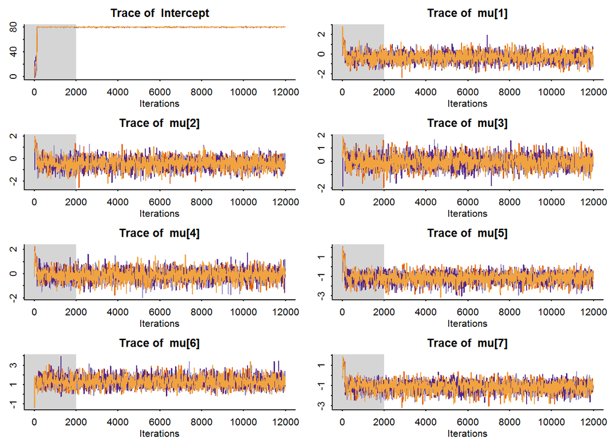

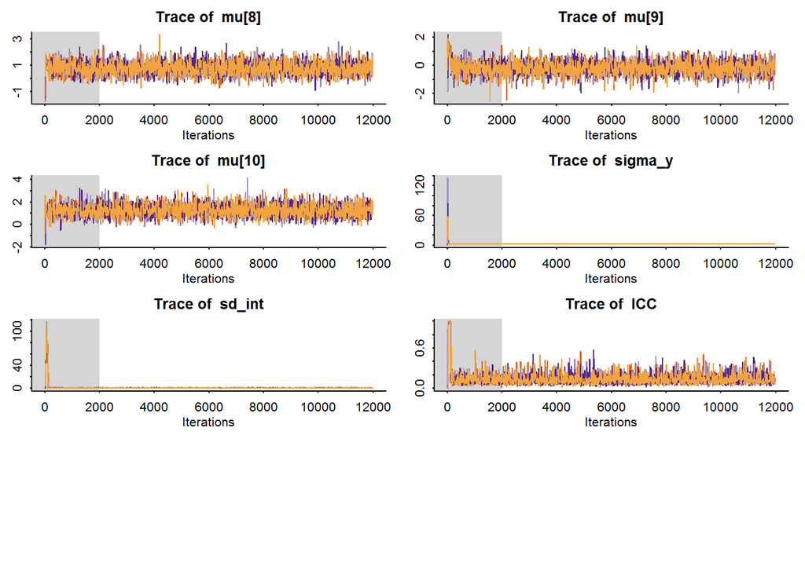

```r
traceplot(fitMain, pars= c('Intercept','mu','sigma_y', 'sd_int', 'ICC'))
```

## Compare to lme4

Again we can compare to the output of *lme4*.

```r
mod_lme = lmer(y~1+ (1|J), data=score2)
summary(mod_lme)
```

```
## Linear mixed model fit by REML ['lmerMod']
## Formula: y ~ 1 + (1 | J)
##    Data: score2
##
## REML criterion at convergence: 2133
##
## Scaled residuals:
##    Min     1Q Median     3Q    Max
## -2.908 -0.680 -0.050  0.744  3.538
##
## Random effects:
##  Groups   Name        Variance Std.Dev.
##  J        (Intercept) 0.472    0.687
##  Residual             4.010    2.002
## Number of obs: 500, groups:  J, 10
##
## Fixed effects:
##             Estimate Std. Error t value
## (Intercept)   79.776      0.235     340
```

```r
ranef(mod_lme)
```

```
## $J
##    (Intercept)
## 1     -0.23048
## 2     -0.31366
## 3     -0.01664
## 4     -0.09183
## 5     -0.83349
## 6      0.94737
## 7     -0.82411
## 8      0.57361
## 9     -0.13223
## 10     0.92146
```

# Save Object/Image

```r
# save.image()
```

# End of file information

```r
### Subsequent files that rely on this one if any
# X.R
# Y.R
```